# Exploring Potential Influencers of Math Student Performance

Lauren Duvall, Shikyna William, Thomas Linden

*2025-04-21*

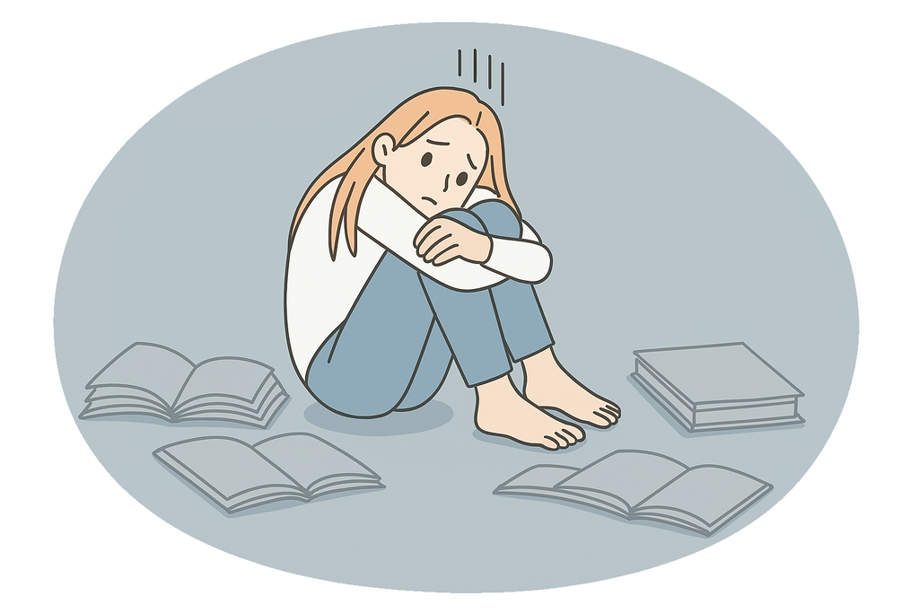

# Introduction

- Dataset: [UCI Machine Learning Repository](https://www.kaggle.com/datasets/adilshamim8/math-students/data)
- Topic: Student performance in math programs
- Collection:
  - Two Portuguese secondary schools
  - School reports and questionaires
- Features: Academic, personal, and social aspects of a student’s life

### Why Is This Interesting?

- Clean, Structured and Small
- Focused on Math Performance: More opportunity for in-depth insights
- Rich Demographic Features: Gender, parental education, lunch type, etc
- Equity and Policy: Can explore impact of social and economic factors
- Portugal Differences
  - Highschool is 3 years; 15-18 years old
  - Each year subdivided into thirds
  - Drinking age - 18
  - Age of consent (relationship status) - 14

# Objective

- Identify significant influencers of math performance
- Test the data to see if reality rejects our hypotheses

### Categories Analyzed

- Logistics & School Choice
- School & Demographics
- Family Background
- Academic Support & Study Habits
- Activities & Social Life
- Health & Lifestyle
- Academic Performance

# Load Packages

- **dplyr** for basic data manipulation.
- **DT / kableExtra** to display the data tables.
- **tidyr** for table pivots.
- **ggplot2** for creating plots.
- **plotly** to add interactivity to the plots.
- **GGally** for ggparacord()’s parallel coordinates chart.
- **ggridges** for ridge plot.
- **patchwork** for side by side plots.
- **ggforce** for plot annotations.

# Data Cleaning

- transmute(): Factors and levels.
- Missing values?

| school | sex | age | address | fam_size | parental_stat | mom_edu | dad_edu | mom_job | dad_job | attend_reason | guardian | travel_time | study_time | failures | school_support | family_support | extra_paid_classes | activities | nursery_school | pursue_higher_edu | internet_use | romantic | family_relationship | free_time | go_out_w_friends | workday_alcohol | weekend_alcohol | health | absences | … |
| --- | --- | --- | --- | --- | --- | --- | --- | --- | --- | --- | --- | --- | --- | --- | --- | --- | --- | --- | --- | --- | --- | --- | --- | --- | --- | --- | --- | --- | --- | --- |
| GP | F | 18 | U | GT3 | A | 4 | 4 | at_home | teacher | course | mother | 2 | 2 | 0 | yes | no | no | no | yes | yes | no | no | 4 | 3 | 4 | 1 | 1 | 3 | 6 | … |
| GP | F | 17 | U | GT3 | T | 1 | 1 | at_home | other | course | father | 1 | 2 | 0 | no | yes | no | no | no | yes | yes | no | 5 | 3 | 3 | 1 | 1 | 3 | 4 | … |
| GP | F | 15 | U | LE3 | T | 1 | 1 | at_home | other | other | mother | 1 | 2 | 3 | yes | no | yes | no | yes | yes | yes | no | 4 | 3 | 2 | 2 | 3 | 3 | 10 | … |
| GP | F | 15 | U | GT3 | T | 4 | 2 | health | services | home | mother | 1 | 3 | 0 | no | yes | yes | yes | yes | yes | yes | yes | 3 | 2 | 2 | 1 | 1 | 5 | 2 | … |
| GP | F | 16 | U | GT3 | T | 3 | 3 | other | other | home | father | 1 | 2 | 0 | no | yes | yes | no | yes | yes | no | no | 4 | 3 | 2 | 1 | 2 | 5 | 4 | … |
| GP | M | 16 | U | LE3 | T | 4 | 3 | services | other | reputation | mother | 1 | 2 | 0 | no | yes | yes | yes | yes | yes | yes | no | 5 | 4 | 2 | 1 | 2 | 5 | 10 | … |
| GP | M | 16 | U | LE3 | T | 2 | 2 | other | other | home | mother | 1 | 2 | 0 | no | no | no | no | yes | yes | yes | no | 4 | 4 | 4 | 1 | 1 | 3 | 0 | … |
| GP | F | 17 | U | GT3 | A | 4 | 4 | other | teacher | home | mother | 2 | 2 | 0 | yes | yes | no | no | yes | yes | no | no | 4 | 1 | 4 | 1 | 1 | 1 | 6 | … |
| GP | M | 15 | U | LE3 | A | 3 | 2 | services | other | home | mother | 1 | 2 | 0 | no | yes | yes | no | yes | yes | yes | no | 4 | 2 | 2 | 1 | 1 | 1 | 0 | … |
| GP | M | 15 | U | GT3 | T | 3 | 4 | other | other | home | mother | 1 | 2 | 0 | no | yes | yes | yes | yes | yes | yes | no | 5 | 5 | 1 | 1 | 1 | 5 | 0 | … |

[output cut: 389 more lines]

# Key Terms

- **School**: Either Gabriel Pereira or Mousinho da Silveira
- **Address**: Urban or Rural
- **Attendance Reason**: Close to ‘home’, school ‘reputation’, ‘course’ preference or ‘other’
- **Extra Paid Classes**: Extra paid classes within the course subject (Math or Portuguese). Yes or No.
- **Nursery School**: Portugal’s version of Pre-School. Attended? Yes or No.
- **Family Support**: Family educational suppor. Yes or No.
- **Family Relationship**: Quality of family relationships. Scale from 1-5, very bad to excellent.
- **Workday Alcohol**: How much drinking during the week. Scale from 1-5, low to high level of drinking.
- **Weekend Alcohol**: How much drinking during the weekend. Scale from 1-5, low to high level of drinking.
- **Health**: Current health status. Scale from 1-5, very bad to very good.

# Exploratory Data Analysis

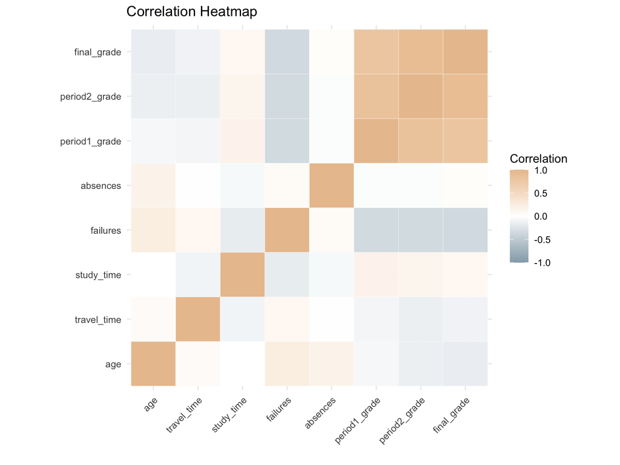

Missing variables: Factors

- Grades from all three periods are strongly positively correlated.
- Grades are negatively correlated with the number of failures.
- Travel time is inversely proportional to study time.
- Number of failures is positively correlated to travel time; negatively correlated with study time.

# School & Demographics

- Do students from different schools show significant differences in final performance? INSIGNIFICANT
- Is there an interaction between romantic relationships and gender on final grade?

### Do students from different schools show significant differences in final grade?

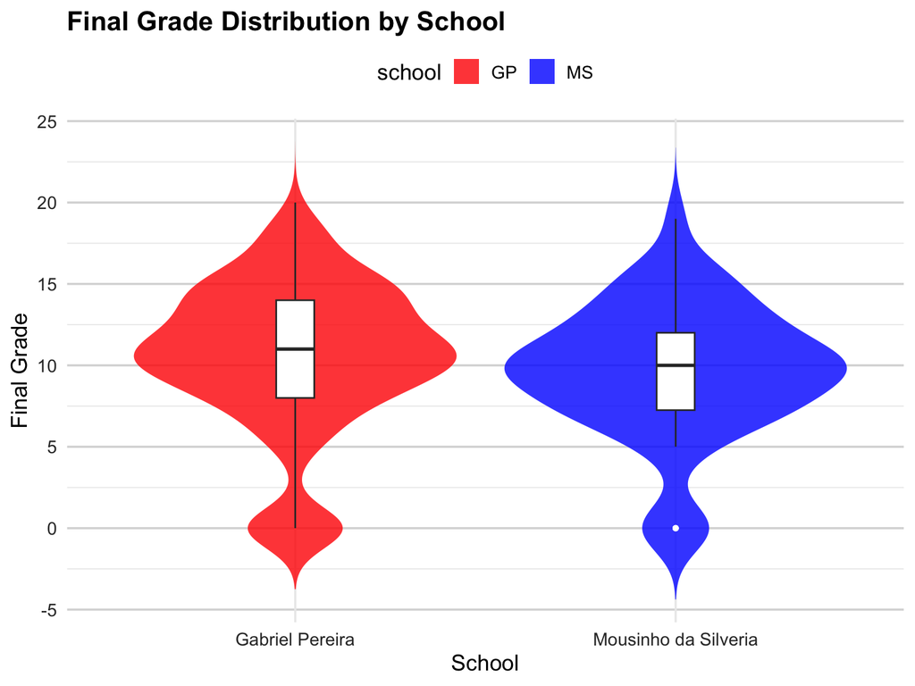

The selection of school has no evidence of affecting student performance.

### Is there an interaction between romantic relationships and gender on the final grade?

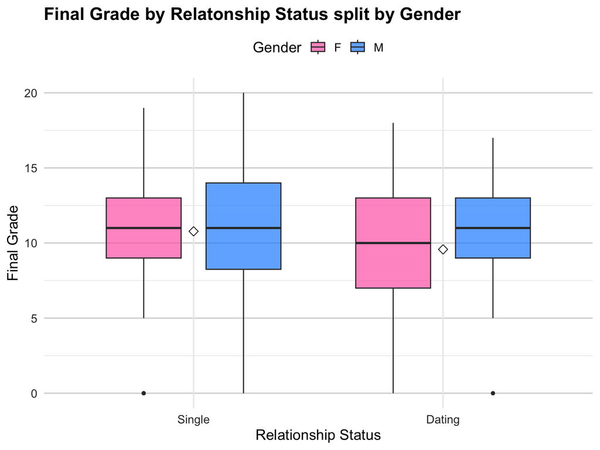

There is correlation between relationship status and final grades when comparing by gender.

Dating Females have a lower median, minimum, and IQR.

# Family Background

- Does having family educational support at home help students perform better in school?

### Does having family educational support at home help students perform better in school?

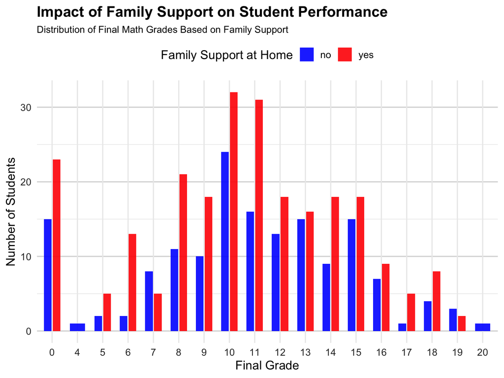

# Academic Support & Study Habits

- Which factors are most predictive of final grades?
- Does weekly study time affect performance consistently across all terms?

### Which factors are most predictive of final grades?

Minimal Impact: ∆ < 1

| Factor | Level | Factor Avg | Difference |
| --- | --- | --- | --- |
| school | GP | 10.49 | 0.11 |
| school | MS | 9.62 | -0.76 |
| sex | F | 9.97 | -0.41 |
| sex | M | 10.83 | 0.45 |
| address | R | 9.51 | -0.87 |
| address | U | 10.63 | 0.25 |
| fam_size | GT3 | 10.13 | -0.25 |
| fam_size | LE3 | 11.00 | 0.62 |
| parental_stat | A | 11.20 | 0.81 |
| parental_stat | T | 10.29 | -0.09 |
| mom_edu | 2 | 9.73 | -0.65 |
| mom_edu | 3 | 10.30 | -0.08 |
| dad_edu | 2 | 10.26 | -0.12 |
| dad_edu | 3 | 10.66 | 0.28 |
| dad_edu | 4 | 11.19 | 0.81 |
| mom_job | other | 9.82 | -0.56 |
| mom_job | services | 11.02 | 0.64 |
| mom_job | teacher | 10.79 | 0.41 |
| dad_job | at_home | 10.00 | -0.38 |
| dad_job | other | 10.18 | -0.20 |
| dad_job | services | 10.24 | -0.14 |
| attend_reason | course | 9.78 | -0.60 |
| attend_reason | home | 10.26 | -0.12 |
| attend_reason | other | 11.17 | 0.79 |
| attend_reason | reputation | 11.07 | 0.68 |
| guardian | father | 10.69 | 0.31 |
| guardian | mother | 10.43 | 0.05 |
| school_support | no | 10.52 | 0.14 |
| school_support | yes | 9.43 | -0.95 |
| family_support | no | 10.55 | 0.17 |
| family_support | yes | 10.27 | -0.11 |
| extra_paid_classes | no | 9.93 | -0.45 |
| extra_paid_classes | yes | 10.92 | 0.54 |
| activities | no | 10.27 | -0.11 |
| activities | yes | 10.49 | 0.11 |
| nursery_school | no | 9.81 | -0.57 |
| nursery_school | yes | 10.54 | 0.15 |
| pursue_higher_edu | yes | 10.57 | 0.19 |
| internet_use | yes | 10.62 | 0.24 |
| romantic | no | 10.78 | 0.40 |
| romantic | yes | 9.58 | -0.81 |
| family_relationship | 1 | 10.62 | 0.24 |
| family_relationship | 2 | 9.89 | -0.49 |
| family_relationship | 3 | 10.04 | -0.34 |
| family_relationship | 4 | 10.36 | -0.02 |
| family_relationship | 5 | 10.69 | 0.31 |
| free_time | 1 | 9.84 | -0.54 |
| free_time | 3 | 9.71 | -0.67 |
| free_time | 4 | 10.43 | 0.05 |
| free_time | 5 | 11.30 | 0.92 |
| go_out_w_friends | 1 | 9.87 | -0.51 |
| go_out_w_friends | 2 | 11.04 | 0.66 |
| go_out_w_friends | 3 | 10.96 | 0.58 |
| go_out_w_friends | 4 | 9.65 | -0.73 |
| workday_alcohol | 1 | 10.68 | 0.30 |
| workday_alcohol | 3 | 10.50 | 0.12 |
| workday_alcohol | 4 | 9.89 | -0.49 |
| workday_alcohol | 5 | 10.67 | 0.29 |
| weekend_alcohol | 1 | 10.74 | 0.35 |
| weekend_alcohol | 2 | 9.94 | -0.44 |
| weekend_alcohol | 3 | 10.72 | 0.34 |
| weekend_alcohol | 4 | 9.69 | -0.69 |
| weekend_alcohol | 5 | 10.14 | -0.24 |
| health | 2 | 10.22 | -0.16 |
| health | 3 | 10.01 | -0.37 |
| health | 4 | 9.93 | -0.45 |
| health | 5 | 10.40 | 0.02 |

Significant Impact: ∆ ≥ 1.5

| Factor | Level | Factor Avg | Difference |
| --- | --- | --- | --- |
| mom_edu | 0 | 13.00 | 2.62 |
| mom_edu | 1 | 8.68 | -1.70 |
| dad_edu | 0 | 13.00 | 2.62 |
| mom_job | health | 12.15 | 1.77 |
| dad_job | teacher | 11.97 | 1.58 |
| pursue_higher_edu | no | 6.80 | -3.58 |

Compared all factors’ average to overall average.

### Which factors are most predictive of final grades?

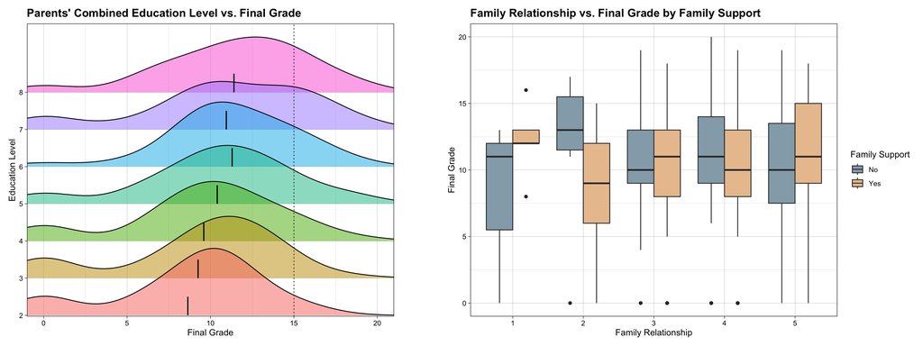

**Left:** Students’ average final grade increases with higher parental education.

**Right:** No relationship between final grade and either family relationship quality / educational support.

### Which factors are most predictive of final grades?

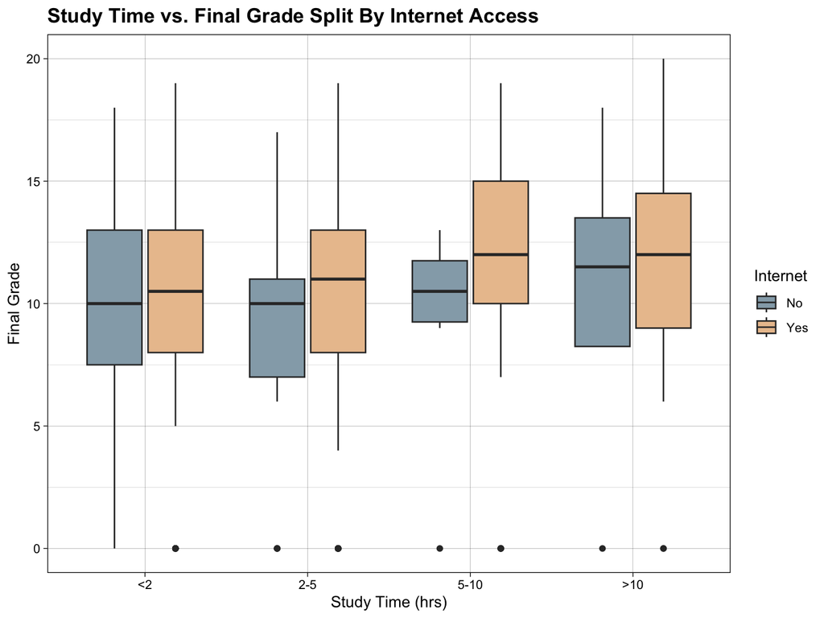

Final grades are marginally better for students with internet access at home.

### Does weekly study time affect performance consistently across all terms?

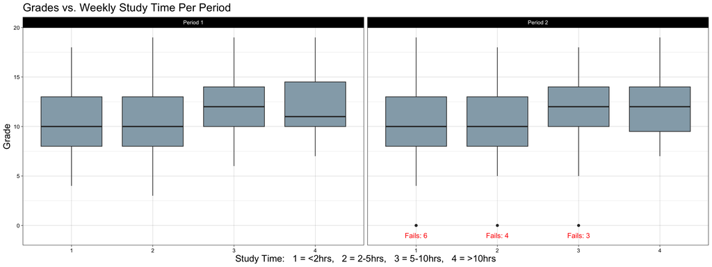

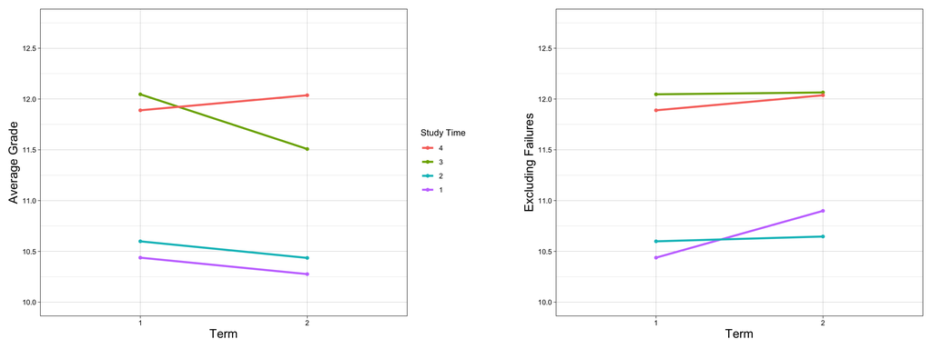

**Top:** Higher study times = higher grades.

**Bottom Right:** Excludes failed students from average grade calculations- all trends now positive.

# Activities and Social Life

- Do romantic relationships affect student performance?
- Is there a link between extracurricular activities and absences?

### Do romantic relationships affect student performance?

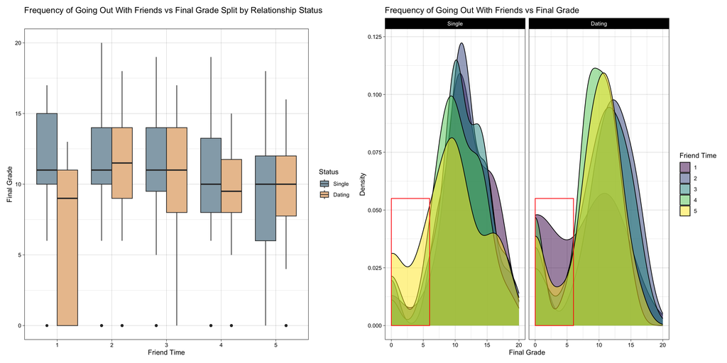

### Is there a link between extracurricular activities and absences?

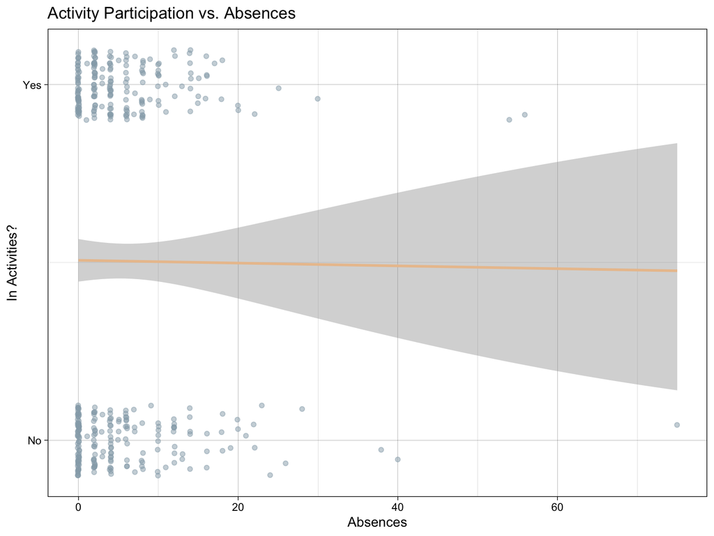

A student’s participation in activities is not a strong indicator of their absence from classes.

# Health & Lifestyle

- What is the relationship between alcohol consumption (weekdays Dalc vs weekends Walc) and final grades?
- Do students with internet access and more activities have more school absences than others?

### What is the relationship between alcohol consumption (weekdays Dalc vs weekends Walc) and final grades?

```
## # A tibble: 5 × 3
## # Groups:   weekend_alcohol [5]
##   weekend_alcohol AvgFinalGrade     n
##   <ord>                   <dbl> <int>
## 1 1                       10.7    151
## 2 2                        9.94    89
## 3 3                       10.7     80
## 4 4                        9.69    51
## 5 5                       10.1     28
```

```
## # A tibble: 5 × 3
## # Groups:   workday_alcohol [5]
##   workday_alcohol AvgFinalGrade     n
##   <ord>                   <dbl> <int>
## 1 1                       10.7    280
## 2 2                        9.25    75
## 3 3                       10.5     26
## 4 4                        9.89     9
## 5 5                       10.7      9
```

### Do students with internet access and more activities have more school absences than others?

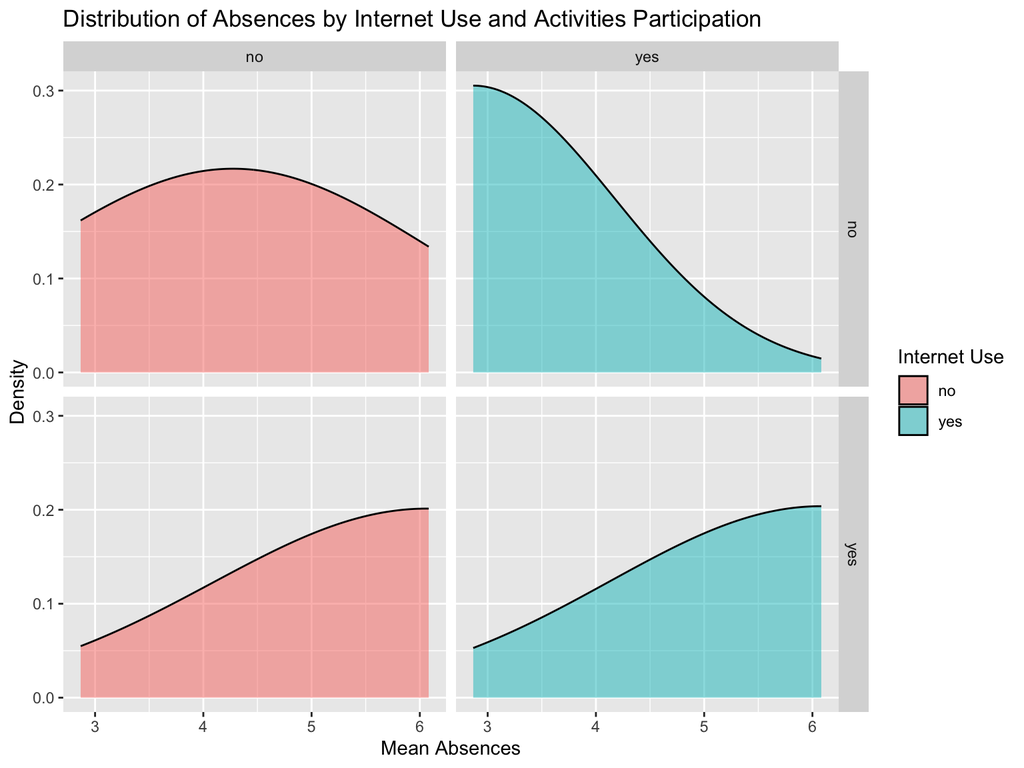

# Academic Performance

- Do students who fail more subjects in the past continue to perform poorly in current grading periods?
- How consistent are students’ performances across G1, G2, and G3? Is there improvement or decline over time?

### Do students who fail more subjects in the past continue to perform poorly in current grading periods?

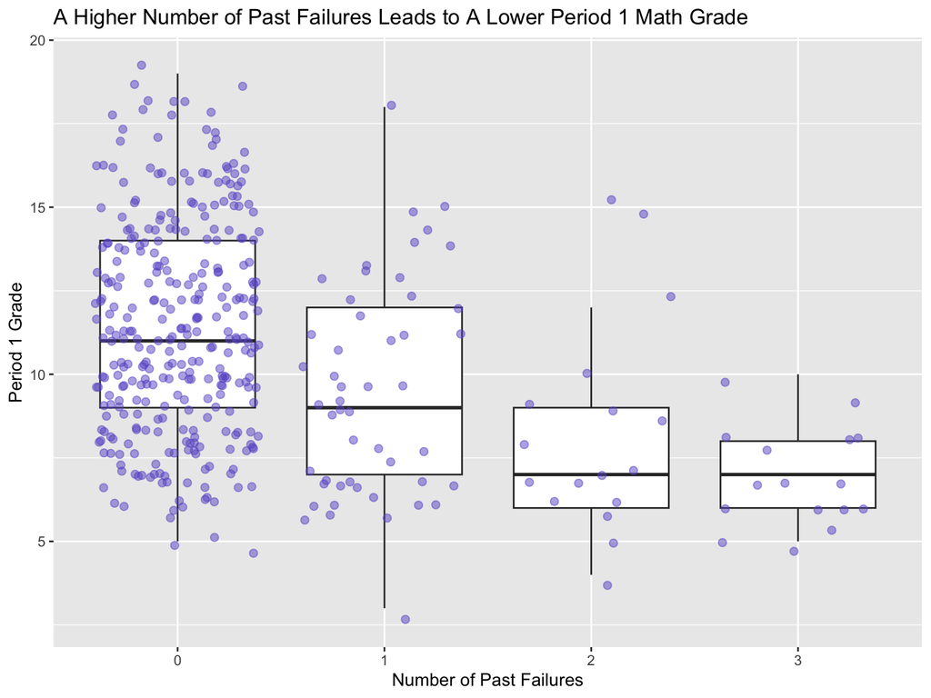

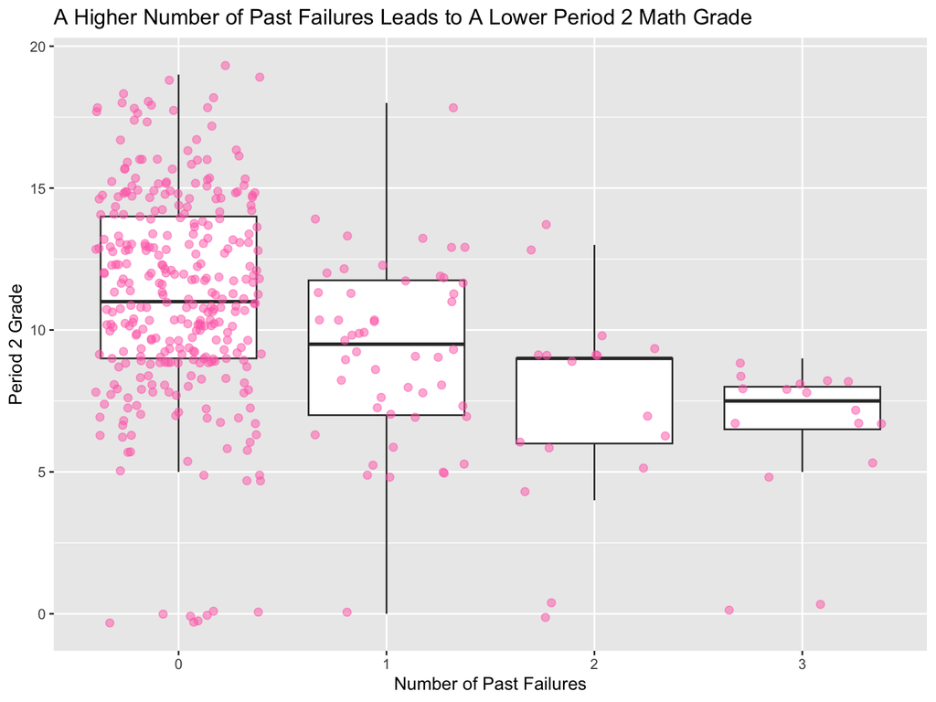

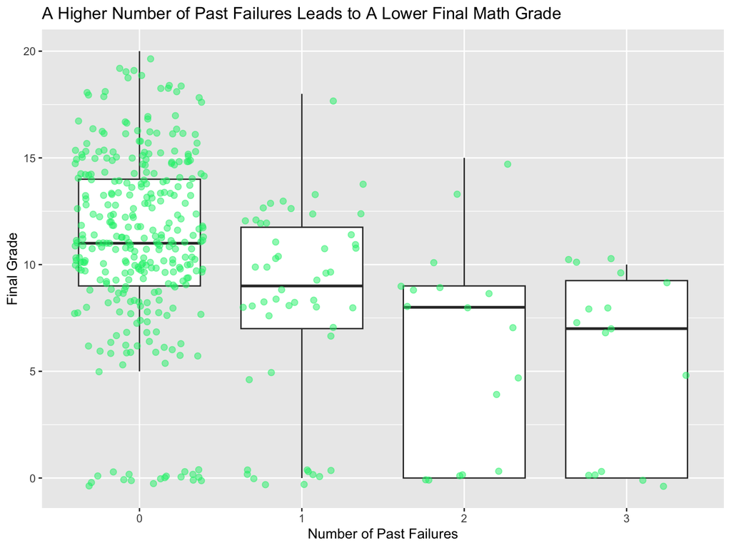

Students who have failed more often in the past have a lower final grade average.

### How consistent are students’ performances across G1, G2, and G3? Is there improvement or decline over time?

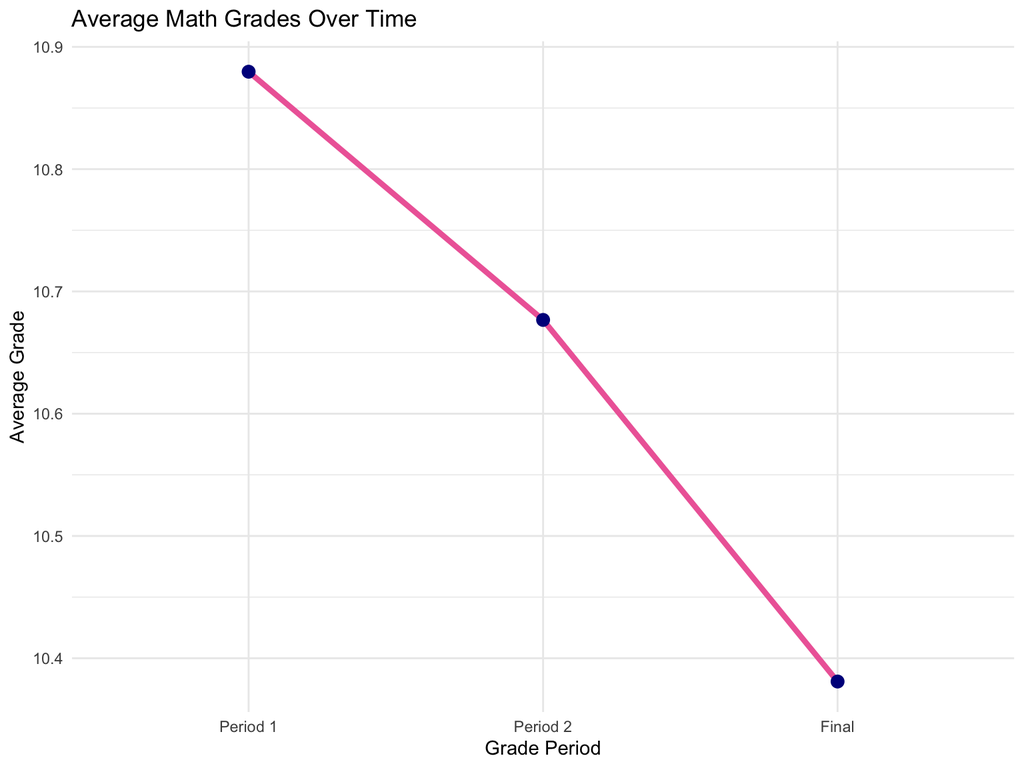

There was a decline in average math grade per grading period over time.

# Conclusions

### Limitations

- Bias: Only covers 2 schools in Portugal.
- Subject: Focused only on math.
- Truthfulness: Relies on student honesty.

### Future Steps

- Prediction: Use ML for larger population predictions.
- Mental Health: Append data on sleep and stress.
- Global Comparison: Compare with other regions.

# References

> Shamim, A. (n.d.). Math-Students Performance Data [Data set]. Kaggle. https://www.kaggle.com/datasets/adilshamim8/math-students/data

> Dua, D., & Graff, C. (2017). Student Performance Data Set. UCI Machine Learning Repository. https://archive.ics.uci.edu/dataset/320/student+performance

> P. Cortez and A. Silva. Using Data Mining to Predict Secondary School Student Performance. In A. Brito and J. Teixeira (Eds.), Proceedings of 5th FUture BUsiness TEChnology Conference (FUBUTEC 2008), pp. 5-12, Porto, Portugal, April 2008, EUROSIS, ISBN 978-9077381-39-7.